# Did test-optional policies change college selectivity?

Jon Ericson jon@jlericson.com

2024-11-13

Like every other part of society, 2020 had a huge impact on college admissions. In 2019 there were 1,804 schools that required SAT scores to be considered for admission. By 2021, the number had dropped to 185. For the most part, schools still *considered* SATs if they were submitted (“test optional”), but 657 schools don’t even accept test scores (“test blind”) as a part of the application process. While these changes caused a lot of confusion for high school students and their parents, it’s less clear anything changed in terms of acceptance rates.

The Department of Education releases data, including [acceptance rates](https://beta.buildcivitas.com/t/does-acceptance-rate-tell-us-which-are-the-best-schools/261), about thousands of schools each year. With the exception of test-blind and non-selective schools, the data includes median SAT scores from incoming freshmen. Unsurprisingly, the top schools sorted by test scores are some of the most selective and highly regarded schools in the nation.

Top 10 schools by decending median SAT in 2022–3

| school | acceptance_rate | sat |
| --- | --- | --- |
| Massachusetts Institute of Technology | 4.0 | 1560 |
| Harvard University | 3.2 | 1550 |
| Stanford University | 3.7 | 1550 |
| Princeton University | 5.7 | 1550 |
| Duke University | 6.3 | 1550 |
| Dartmouth College | 6.4 | 1550 |
| Johns Hopkins University | 7.5 | 1550 |
| Yale University | 4.6 | 1540 |
| Brown University | 5.1 | 1540 |
| University of Chicago | 5.4 | 1540 |

Reported SAT scores come from *enrolled* students.[^1] That means this data reflects the academic standards (as expressed by test scores) of the admissions process and are less easily manipulated than admission rates.

Even so, a graph of all schools that reported median SAT scores in the 2022-2023 school year, shows a strong correlation with acceptance rate.

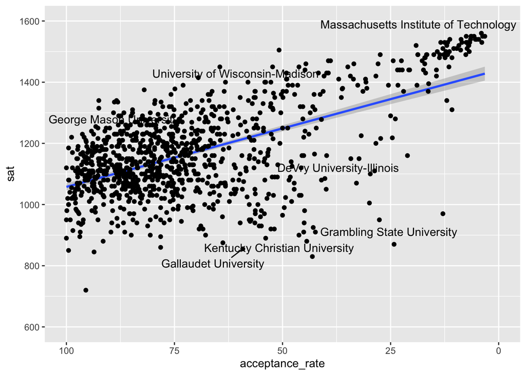

Figure 1: Median SAT scores for freshman and admission rate for schools reporting this data in 2022–3

I’ve labeled MIT, which is at the top of the list, University of Wisconsin, which accepts almost exactly half of the students who apply and George Mason University, which has an acceptance rate of 90%. The bulk of the sample accepts most applicants. I’ve also labeled a handful of schools that fall under the blue line, which represents a simple linear regression. These are schools have much lower median SAT than would be expected from their acceptance rate.

College applications include a huge amount of data about students:

- GPA and class rank
- Academic transcripts
- Personal essays
- Extra-curricular activities
- Letters of recommendation
- Test scores (for schools that consider them)

One way admissions offices *could* use that data would be to consider each applicant individually and evaluate all the data in their file. But it seems likely most admissions are based on a combination of test scores and GPA with other factors only coming into play around the edges. This would greatly simplify the process for students above the academic threshold and leave more time for staff to evaluate students below the cutoff.

According to the CollegeBoard [1050 is average SAT score and the top decile starts at 1350](https://satsuite.collegeboard.org/sat-school-day/scores/understanding-scores/whats-a-good-score). They also provide [percentiles for each SAT score](https://research.collegeboard.org/reports/sat-suite/understanding-scores/sat). The median score at MIT is 1560, which is 99<sup>th</sup> percentile for all students who took the test. Less selective schools would have lower score thresholds in order to admit enough students to meet enrollment targets. Since SAT scores are designed to fit a normal distribution, scores near the extremes represent a smaller portion of the population than average scores.

Indeed the cumulative distribution of 25% SAT scores from schools comes close to matching the cumulative distribution for all students who took the test. Scores from students who actually enrolled skew higher since people who scored lower than average are more likely to either not attend college or enroll in a non-selective school that does not report SAT scores.

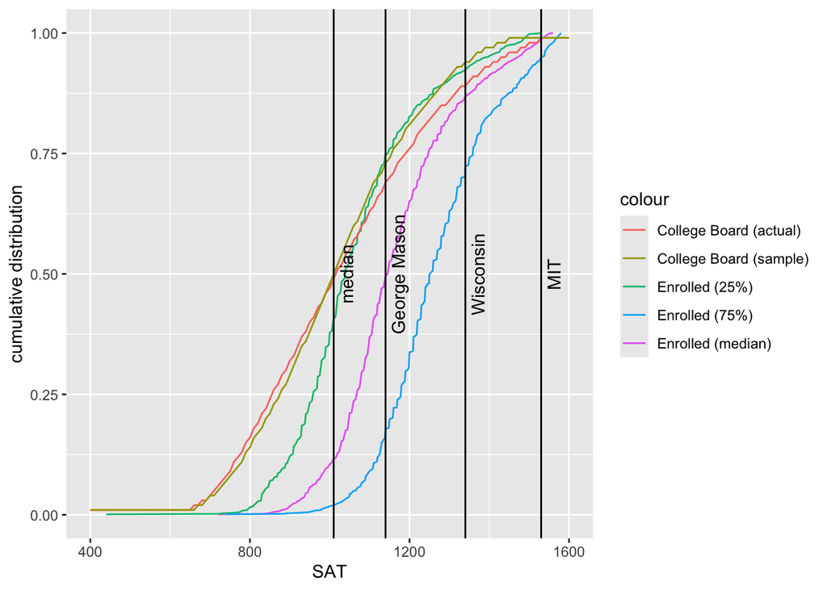

Figure 2: Cumulative distribution of SAT score reported by the College Board and by school for their incoming class (2022–3)

If schools do have an SAT threshold, we can estimate what it might be based on acceptance rate. Figure 1 suggests a simple linear regression should work well for this purpose.

In order to refine the model, I excluded schools that enrolled 200 or fewer students in 2022–3. These schools tend to skew the results since a relatively small number of applications can decrease acceptance rates in a way that doesn’t tell you very much about the selectivity of the school. For instance, some of the top schools for music, art, drama and design have low acceptance rates and don’t use test scores as a primary determinant. I also excluded:

- schools with a religious affiliation,
- for-profit schools and
- Historically Black Colleges and Universities (HBCUs).

These tend to be outliers since they have selection criteria beyond SAT score. I don’t mean these are in any way inferior schools, but rather they don’t fit a selectivity model based on SAT score.

In addition I’m using the 25<sup>th</sup> percentile (first quartile) data point rather than median SAT because:

1. The top schools (MIT, Johns Hopkins, etc.) come very close to the maximum SAT score of 1600. Using the lower SAT gives more space for these schools to separate from each other.
2. For students considering applying to elite schools, a lower bound can be useful. While 25% of enrolled students will (by definition) have lower SAT scores, it seems likely they will be admitted based on factors other than SAT.
3. Median SAT was introduced in the IPEDS data in the 2022–3 academic year. In order to have historical data (going back to 2001–2) we must pick ether the 25% or the 75% number.

Between eliminating outliers and using the 25% SAT data point, we have an even stronger correlation, especially for the most elite schools.

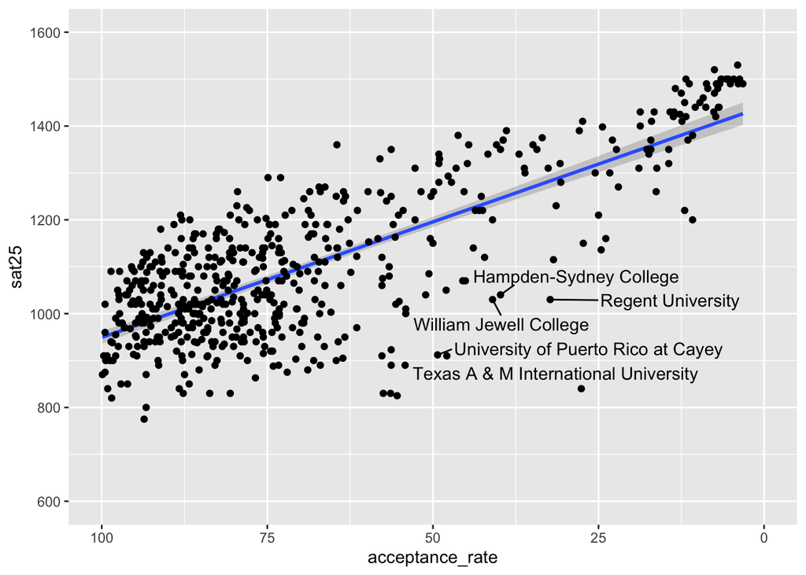

Figure 3: First quartile SAT scores for freshman and admission rate for selected schools in 2022–3

There are still some schools in this sample with low acceptance rates (< 50%) and low SATs (< 1050). As you can see, these are not particularly well-known schools. I haven’t identified a reason for these outliers, so I’m leaving them in to avoid over-fitting. A simple linear model fits the data rather well.

|  | sat25 |  |  |
| --- | --- | --- | --- |
| Predictors | Estimates | CI | p |
| (Intercept) | 1442.01 | 1416.94 – 1467.08 | **<0.001** |
| acceptance rate | -4.93 | -5.27 – -4.59 | **<0.001** |
| Observations | 557 |  |  |
| R<sup>2</sup> / R<sup>2</sup> adjusted | 0.595 / 0.594 |  |  |

This model has an R<sup>2</sup> of 0.59 which indicates excellent fit for data about human behavior. Using 2019 data, we can compare the projected SAT scores to the pre-COVID, pre-test-optional era.

| school | acceptance_rate | sat25_projected | sat25_2019 |
| --- | --- | --- | --- |
| California Institute of Technology | 2.7 | 1429 | 1530 |
| University of California-Berkeley | 11.3 | 1386 | 1320 |
| University of California-Los Angeles | 8.6 | 1400 | 1290 |
| University of California-San Diego | 23.7 | 1325 | 1260 |
| California Polytechnic State University-San Luis Obispo | 30.4 | 1292 | 1240 |
| University of California-Santa Barbara | 25.8 | 1315 | 1230 |
| CUNY Bernard M Baruch College | 49.5 | 1198 | 1220 |
| University of Washington-Seattle Campus | 47.5 | 1208 | 1220 |
| New Mexico Institute of Mining and Technology | 74.4 | 1075 | 1210 |
| University of California-Irvine | 21.2 | 1338 | 1190 |

Our model passes the smell test for the most part. What’s more, the linear model fits the data going back to 2014–5.[^2] Graphing schools based on our criteria, we see that the sloop of the best fit line stays more or less constant at -5 points of SAT for each percentage point of admission rate. The intercept (where SAT would be projected for a theoretical school that accepts 0% of applications) increases steadily from 1304 in 2014 to 1442 in the most recent admission season.

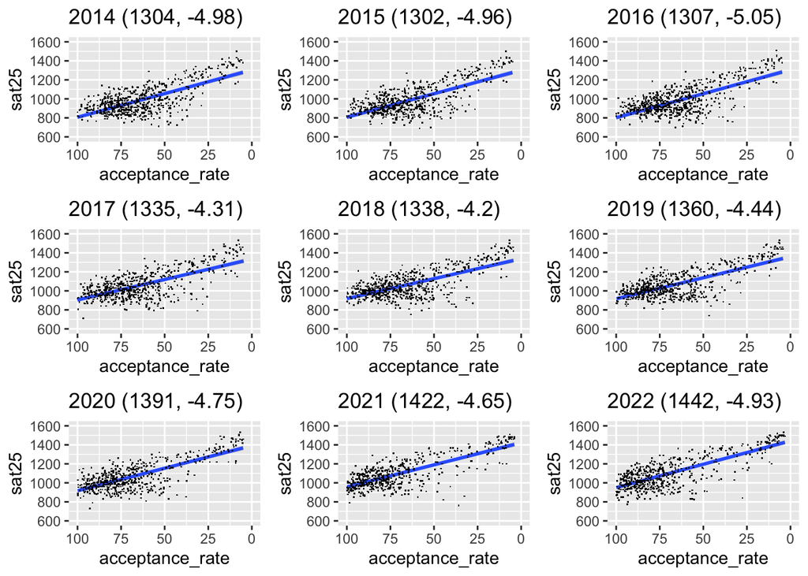

Figure 4: First quartile SAT scores for freshman and admission rate for schools reporting this data from 2014–5 to 2022–3

Nothing, not COVID and not test-optional/test-blind, changed the correlation between acceptance rate and 25<sup>th</sup> percentile SAT. In other words, we can make a pretty good guess at the relative academic standards for admission at two difference schools based solely on the percentage of applications that are offered admission.

Still, there’s an even better way to predict SAT scores for schools that haven’t published that number recently. As it turns out, the persistence model works even better than extrapolating from acceptance rate. That is, we can predict 2022–3 SAT scores just from the SAT scores a school reported in 2019–20 (before many stopped considering SAT).

|  | sat25 |  |  |
| --- | --- | --- | --- |
| Predictors | Estimates | CI | p |
| (Intercept) | -66.70 | -105.65 – -27.75 | **0.001** |
| sat25 2019 | 1.08 | 1.05 – 1.12 | **<0.001** |
| Observations | 488 |  |  |
| R<sup>2</sup> / R<sup>2</sup> adjusted | 0.879 / 0.879 |  |  |

Persistence explains 0.88 of the variation, which is strong evidence individual admissions offices have an SAT threshold whether explicitly or implicitly. Adding in acceptance rate does account for slightly more of the variation and it is a significant predictor.

|  | sat25 |  |  |
| --- | --- | --- | --- |
| Predictors | Estimates | CI | p |
| (Intercept) | 93.55 | 15.41 – 171.69 | **0.019** |
| sat25 2019 | 0.98 | 0.92 – 1.03 | **<0.001** |
| acceptance rate | -0.73 | -1.04 – -0.42 | **<0.001** |
| Observations | 488 |  |  |
| R<sup>2</sup> / R<sup>2</sup> adjusted | 0.884 / 0.884 |  |  |

Of course this analysis is looking at a large swath of schools and there could be individual schools that handle admissions on a more case-by-case basis. Schools that don’t report the SAT distribution of their incoming enrolled students weren’t included and therefore might not have minimum thresholds for GPA or other academic measures. However it seems likely that the majority of schools consider SAT and or GPA for the majority of admissions decisions. 2020 didn’t likely change that reality.

[^1]: See the discussion of potential changes in [“Report and Suggestions from IPEDS Technical Review Panel #64: Meeting the Moment: Modernizing the IPEDS Admissions Survey Component”](https://edsurveys.rti.org/IPEDS_TRP_DOCS/prod/documents/TRP64_Summary.pdf)
[^2]: The database schema changed that year and I haven’t gotten around to importing the older schema.